# Project Python Foundations: FoodHub Data Analysis

#### food_preparation_time

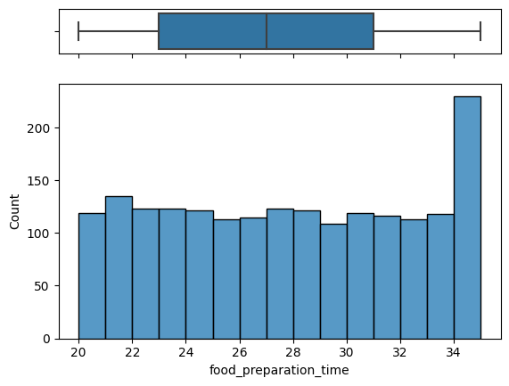

```python
dualplot(df['food_preparation_time'])
```

A little surprising that this is just a flat distribution, except for at 35. I suspect a few of those might have gone past 35 and were reported as 35, But otherwise, extremely balanced (and non-normal?) distribution.

#### delivery_time

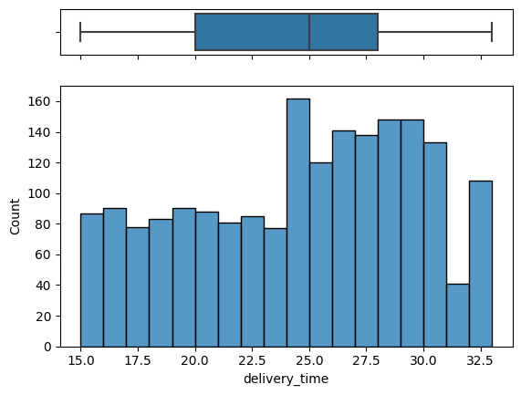

```python
dualplot(df['delivery_time'])
```

Again, I expected this to be more of a bell curve. You're going to have varying delivery time but since it depends on multiple varying factors you'd expect some more clumping toward an average.

### **Question 7**: Which are the top 5 restaurants in terms of the number of orders received? [1 mark]

```python
# value_counts() will group by restaurant and report in order of decreasing frequency
df['restaurant_name'].value_counts().head()
```

```
Shake Shack                  219
The Meatball Shop            132
Blue Ribbon Sushi            119
Blue Ribbon Fried Chicken     96
Parm                          68
Name: restaurant_name, dtype: int64
```

#### Observations:

The most popular restaurants are, in order: Shake Shack, The Meatball Shop, Blue Ribbon Sushi, Blue Ribbon Fried Chicken, and Parm.

### **Question 8**: Which is the most popular cuisine on weekends? [1 mark]

```python
#Filter df where "day_of_the_week" is "Weekend", then give value counts of "cuisine_type"
df.loc[df['day_of_the_week']=="Weekend",'cuisine_type'].value_counts().head()
```

```
American    415
Japanese    335
Italian     207
Chinese     163
Mexican      53
Name: cuisine_type, dtype: int64
```

#### Observations:

The most popular cuisine type on weekends is "American".

### **Question 9**: What percentage of the orders cost more than 20 dollars? [2 marks]

```python
#Divide the number of rows of the filtered df (only costs greater than 20) by the total rows
cost = 20.00
per = (df.loc[df['cost_of_the_order'] > cost].shape[0]) / (df.shape[0])
print(f"The percentage of orders that costs more than {cost} is {per:.1%}.")
```

```
The percentage of orders that costs more than 20.0 is 29.2%.
```

### **Question 10**: What is the mean order delivery time? [1 mark]

```python
print(f"The mean order delivery time is {df['delivery_time'].mean():.1f} minutes.")
```

```
The mean order delivery time is 24.2 minutes.
```

### **Question 11:** The company has decided to give 20% discount vouchers to the top 3 most frequent customers. Find the IDs of these customers and the number of orders they placed. [1 mark]

```python
df['customer_id'].value_counts().head(3)
```

```
52832    13
47440    10
83287     9
Name: customer_id, dtype: int64
```

#### Observations:

Congratulations Customers 52832, 47440, and 83287 for being the Top 3 users with 13, 10, and 9 orders placed, respectively.

## Multivariate Analysis

### **Question 12**: Perform a multivariate analysis to explore relationships between the important variables in the dataset. (It is a good idea to explore relations between numerical variables as well as relations between numerical and categorical variables) [10 marks]

One good way to see if there are any relationships between numerical feature is the pairplot, which is just a matrix of scatter/hist plots between each variable.

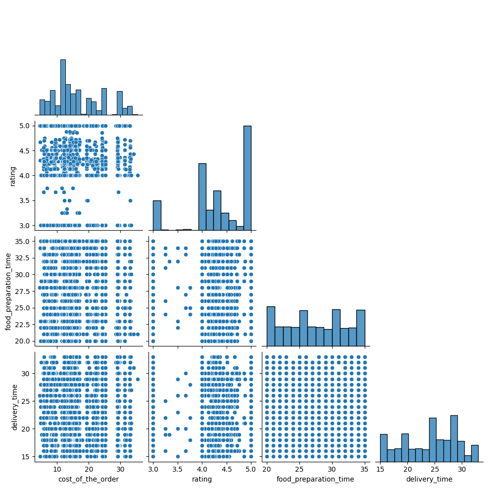

```python
sns.pairplot(df[['cost_of_the_order', 'rating', 'food_preparation_time', 'delivery_time']], corner=True)
```

Huh.

This data looks pretty odd, but I'm not seeing any kind of correlation between any of the two variables. I expected something like having a high preparation tiem or delivery time might result in lower ratings, but not here.

```python
df_cuisine = df.groupby("cuisine_type", as_index=False).agg(
    cost=('cost_of_the_order', np.mean),
    preparation_time=('food_preparation_time', np.mean),
    rating=("rating", np.mean),
    count=('cuisine_type', "count")
  )
```

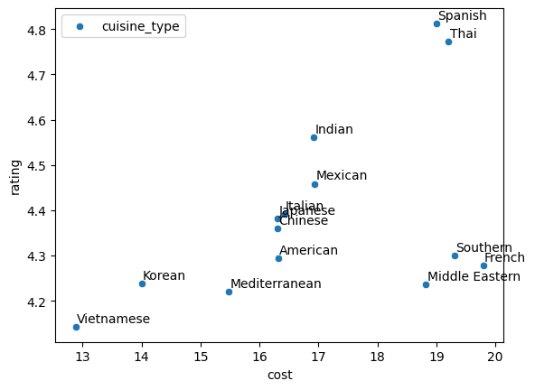

```python
sns.scatterplot(df_cuisine, x="cost", y='rating', label='cuisine_type')
for i, cuisine in enumerate(df_cuisine['cuisine_type']):
  plt.annotate(cuisine, (df_cuisine['cost'][i]+0.02, df_cuisine['rating'][i]+0.01))
```

Ahh, here we get some insight.

There is a positive correlation between cost and rating when you sort by cuisine type. Vietnamese is the lowest cost but also the lowest rated food, whereas Spanish and Thai are both the highest. There are three cuisines (Southern, French, Middle Eastern) that are expensive but don't rate as well.

### **Question 13:** The company wants to provide a promotional offer in the advertisement of the restaurants. The condition to get the offer is that the restaurants must have a rating count of more than 50 and the average rating should be greater than 4. Find the restaurants fulfilling the criteria to get the promotional offer. [3 marks]

```python
#In order to answer this properly, I'm gonna have to retrieve the original version of the dataset without the imputed ratings.
#They specifically want restaurants that have 50+ ratings, not just 50+ orders.

#Re-retrieve data (as integers) and filter out "Not given"
df2 = pd.read_csv('foodhub_order.csv')
df2['rating'] = pd.to_numeric(df2['rating'], errors='coerce')
df_ratings = df.dropna()

#Group data by restaurant, then filter for only the ones that meet the conditions
df_byrestaurant = pd.DataFrame()
df_byrestaurant['rating'] = df_ratings.groupby('restaurant_name')['rating'].mean()
df_byrestaurant['count'] = df_ratings.groupby('restaurant_name')['restaurant_name'].count()
df_promo = df_byrestaurant[(df_byrestaurant['rating'] > 4) & (df_byrestaurant['count'] > 50)]

df_promo
```

| restaurant_name | rating | count |
| --- | --- | --- |
| Blue Ribbon Fried Chicken | 4.328125 | 96 |
| Blue Ribbon Sushi | 4.219178 | 119 |
| Parm | 4.128205 | 68 |
| RedFarm Broadway | 4.243902 | 59 |
| RedFarm Hudson | 4.176471 | 55 |
| Shake Shack | 4.278195 | 219 |
| The Meatball Shop | 4.511905 | 132 |

### **Question 14:** The company charges the restaurant 25% on the orders having cost greater than 20 dollars and 15% on the orders having cost greater than 5 dollars. Find the net revenue generated by the company across all orders. [3 marks]

```python
#Going back to the original dataframe, df

#This function calculates what the additional charge would be to the nearest cent
def extra_charge(x):
  cost = x['cost_of_the_order']
  extra = cost*0.25 if cost > 20 else cost*0.15
  return round(extra, 2)

#Apply the function to the dataframe, creating a newcolumn
df['charge'] = df.apply(lambda x: extra_charge(x), axis=1)

print(f"The total revenue generated by these charges is ${df['charge'].sum()}")
```

```
The total revenue generated by these charges is $6172.91
```

### **Question 15:** The company wants to analyze the total time required to deliver the food. What percentage of orders take more than 60 minutes to get delivered from the time the order is placed? (The food has to be prepared and then delivered.) [2 marks]

```python
df['total_time'] = df['food_preparation_time'] + df['delivery_time']
df_filtered = df[df['total_time']>60]

print(f"The percentage of orders that take more than 60 minutes is {df_filtered.shape[0]/df.shape[0]:.1%}.")
```

```
The percentage of orders that take more than 60 minutes is 10.5%.
```

#### Observations:

10.5% of orders take longer than 60 minutes.

### **Question 16:** The company wants to analyze the delivery time of the orders on weekdays and weekends. How does the mean delivery time vary during weekdays and weekends? [2 marks]

```python
df_weekends = df[df['day_of_the_week'] == "Weekend"]
df_weekdays = df[df['day_of_the_week'] == "Weekday"]

print(f"The average delivery time on weekends is {df_weekends['delivery_time'].mean():.1f} minutes, vs. on weekdays it is {df_weekdays['delivery_time'].mean():.1f} minutes.")
```

```
The average delivery time on weekends is 22.5 minutes, vs. on weekdays it is 28.3 minutes.
```

#### Observations:

### Conclusion and Recommendations

### **Question 17:** What are your conclusions from the analysis? What recommendations would you like to share to help improve the business? (You can use cuisine type and feedback ratings to drive your business recommendations.) [6 marks]

### Conclusions:

- The data of individual restaurants is far too disparate to make many conclusions.
- Aggregating by cuisine_type starts to show real patterns in the data.

### Recommendations:

- Look into why orders are so much lower on weekdays. The business model needs to be adjusted to seek profit 7 days of the week, not just 2.
- The customers have to wait at about 6 minutes longer on average for food to be delivered (food preparation time is the same in both cases). Perhaps longer wait times -- especially if they're shown in the app before purchase -- are putting some customers off, but probably not by that amount.
- The most well-liked cuisines are Spanish and Thai, and they are also two of the more expensive cuisines. To get customers to pay more for food they like, highlighting these restaurants in the app and driving customers to them may increase both profit and customer satisfaction.